# Used Cars: Are similar data sets that similar when it comes to modeling?

John Garner, Ronan Wallace, & Amy Plambeck

**The Question** Our group wanted to look into the differences in the used cars being sold in two states: MN and WI. This analysis and research will look into the prediction of car prices set in differing states when other chosen variables are the same.

**The Data** This data originally came from [Kaggle](https://www.kaggle.com/austinreese/craigslist-carstrucks-data/data#vehicles.csv). The data contains information on used cars scraped from various craigslist websites across the US. It was downloaded on January 17th, 2017. Minor data cleaning was performed and a subset of cars from several craigslist sites in MN and WI: minneapolis / st paul, milwaukee, eau claire, la crosse, and madison was taken. The data cleaning included the removal of unneeded variables such as the urls of listings, as well as the correction of certain errors in listings. For instance, we cleared the year of listings when they were marked as 0. No cars were being manufactured in the year 0.

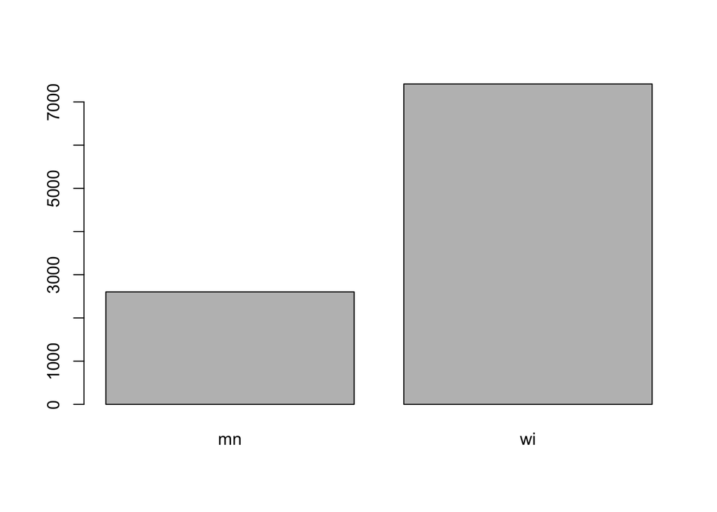

This graph gives us a visual representation of the distribution of cars across both of our chosen states. As seen here, most of the data comes from WI.

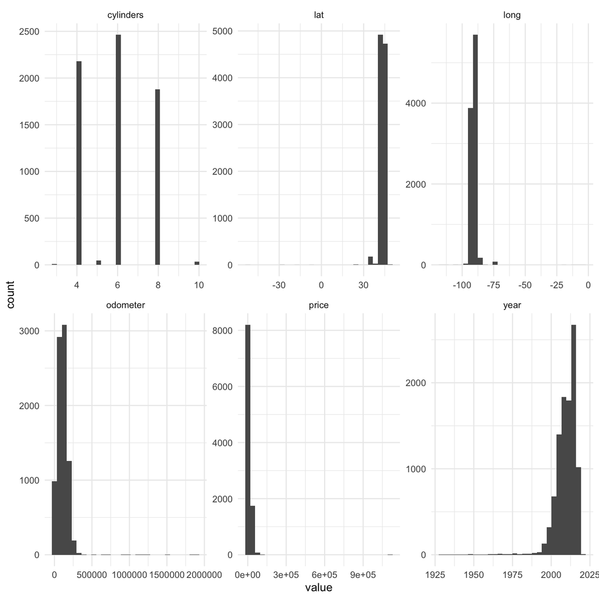

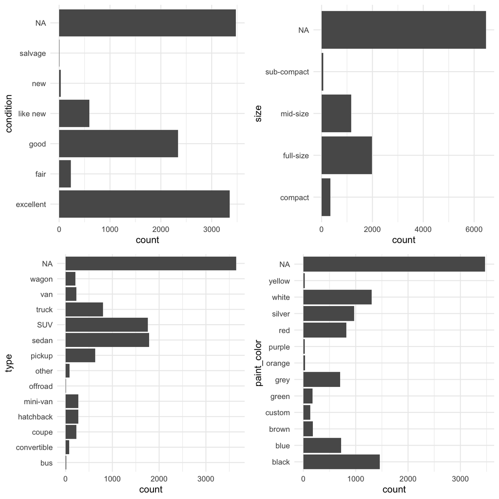

From these graphs we can see that a good amount of our data is missing, indicated as “N/A” in the charts above for the variables of condition, size, type, and paint color.

**The Plan** The plan for our research is to create different models using different modeling methods to predict the price of cars found in MN and WI respectively. We will find the best model for each state, and see if, and how the models and/or the variables differ.

**The Modeling** We started off with simple, easy to create models to predict the price of cars in each state. While these first models were not as accurate as more complicated models created later, taking into account their ease of creation, which is “better” is subjective.

**OLS Model** The first and simplest model we worked with was an ordinary least squares linear model using all of the variables in the dataset. We created one for each of the two sets of state data.

**MN tRMSE for OLS**

```
##      tRMSE
## 1 21305661
```

**WI tRMSE for OLS**

```
##      tRMSE
## 1 6657.913
```

**Decision Tree** One of the better and more accurate models (for both states) we worked with was a decision tree model using all of the variables. While they were more accurate than other models, the two models varied more so. This model also quite nicely visually shows this difference.

**MN Tree**

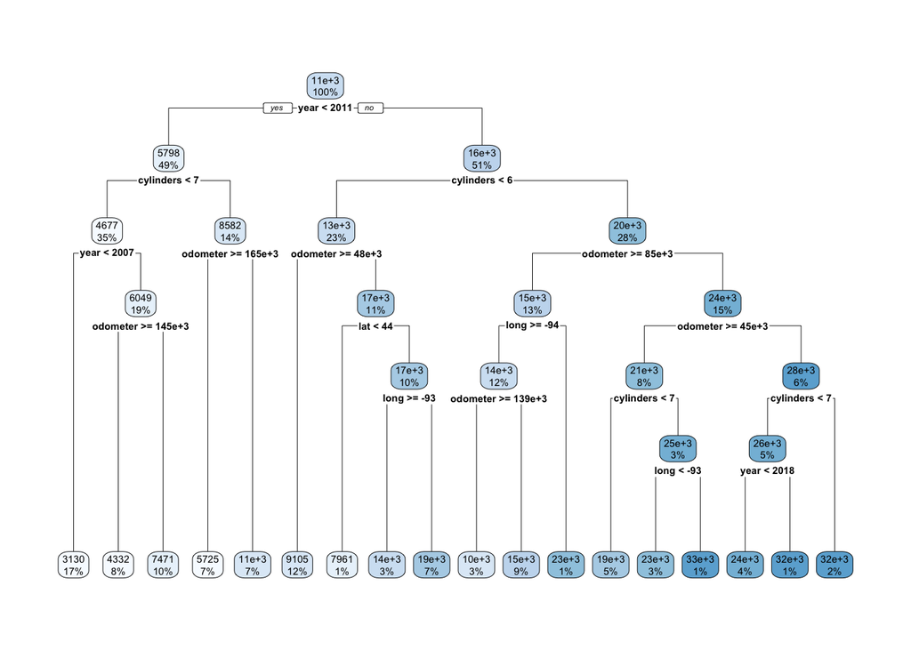

**MN Tree Results**

```
##      cp     RMSE  Rsquared     MAE  RMSESD RsquaredSD   MAESD
## 1 0.005 5878.189 0.5862305 3724.44 1055.94 0.08147938 339.049
```

**WI Tree**

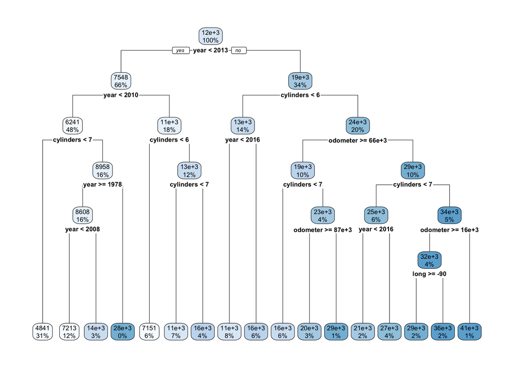

**WI Tree Results**

```
##      cp     RMSE Rsquared      MAE   RMSESD RsquaredSD    MAESD
## 1 0.005 5259.822 0.679588 3566.764 169.2307 0.02978126 168.4532
```

**Conclusion** Our research was not focused around the question of how to predict something the most accurately, but rather the differences that can emerge in seemingly similar models, even when using the same variables and similar data sets. Thus, we would call it a success as we were able to look more closely at this quality, and discuss the ramifications it can have in a model. You should not assume, even if your data is at first seemingly similar, coming from places close to one another or regarding similar items, that your models will be similar. If there is one point of interest to take away from this research, that is it.